# Azure Marketplace

[[edit on GitHub]](https://github.com/chef/chef-web-docs/blob/main/content/azure_marketplace.md)

Chef Automate is an enterprise platform that allows developers, operations, and security engineers to collaborate on application and infrastructure changes with speed and at scale. Chef Automate provides actionable insights across data centers and cloud providers, wherever your nodes live.

Chef Automate is the center of the modern Chef platform, providing users with a single source of truth for infrastructure, security, and application automation. The comprehensive dashboard provides real-time views of your configuration management activity. Chef Automate comes bundled with the latest Chef Infra Server, providing the core tools you need to manage your enterprise infrastructure. Data collection is enabled by default, allowing your nodes to report activity in real-time. This instance is free for 60 days or you can bring your own license (BYOL).

Use this instance with Chef Workstation installed on your laptop or a separate Azure instance.

Chef Workstation includes:

- Chef Infra Client
- Chef InSpec
- Chef Habitat
- `chef` and `knife` command line tools
- Testing tools, such as Test Kitchen and Cookstyle
- Everything else needed to author cookbooks and upload them to the Chef Infra Server.

If you need to run Automate with a high availability (HA) topology, please contact [Chef Support](https://www.chef.io/support).

## Marketplace Deployment

The **Marketplace Deployment** is a test-level Chef Automate environment. This deployment requires an Azure account or subscription. You can provision Chef Automate directly from Azure. This Chef Automate solution requires that you bring your own license (BYOL). New users may try this solution for up to 60 days. Contact us at amp@chef.io to obtain a license.

### Get Started

1. Navigate to Chef Automate on the [Azure Marketplace](https://azuremarketplace.microsoft.com/marketplace/apps/chef-software.chef-automate).

[figure not shown]

2. Select **Get it Now**.

[figure not shown]

3. Sign in to your Microsoft account with your Microsoft account email address.

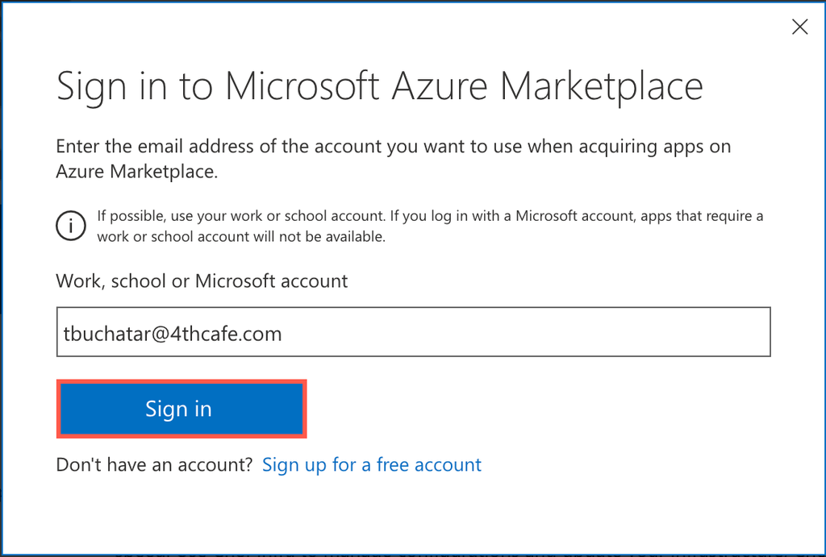

4. Enter your password and select **Sign In**.

[figure not shown]

5. Select **Continue** to accept the Microsoft information terms.

[figure not shown]

### Deploy Automate

1. Select **Create** to create your Chef Automate instance.

[figure not shown]

2. Enter the project details and select **Next**:
   1. `Subscription`: Select the your subscription
   2. `Resource group`: Create new or select an existing one
   3. `Region`: Select the region for your instance

[figure not shown]

3. Enter your custom settings and select **Next: Review + create** to validate your configuration.
   1. `Username`: Example:`chefuser`
   2. `SSH public key`: Copy your existing public key or make a new key pair.
   3. `Size`: The vCPUs and memory for your instance. The recommended minimum is 4vCPUs and 16GB memory. Example: `Standard D4s v3`

[figure not shown]

4. Review your validated configuration and select **Create** to deploy Chef Automate.

[figure not shown]

5. Chef Automate takes about 15 minutes to deploy.

[figure not shown]

6. Once the Chef Automate deployment completes, select **Go to resource group**.

[figure not shown]

### Connect

1. On the *Resource group* page for your installation, select the Chef Automate virtual machine (VM), which is named `RESOURCE-GROUP-ipg6-VM`.

[figure not shown]

2. Locate and copy the `Public IP` on the *Virtual machine* page. You will use this to connect to your VM.

[figure not shown]

3. From the command line, connect to your VM:

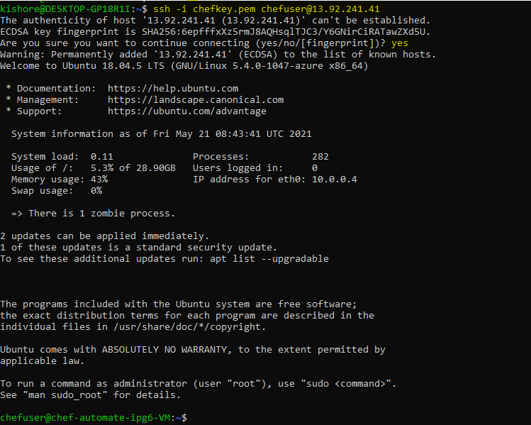

   ```bash
   ssh -i chefkey.pem chefuser@13.92.241.41
   ```

1. Get your Chef Automate URL and login credentials from the command line:

   ```bash
   sudo cat /root/automate-credentials.toml
   ```

   Which returns something like:

   ```
   url = "https://chef-automate-example.eastus.cloudapp.azure.com"
   username = "admin"
   password = "EXAMPLE1234567890abcdefghijklmno"
   ```

2. Open your favorite browser and Access the Chef Automate URL and Select **Advanced** and continue as shown below:

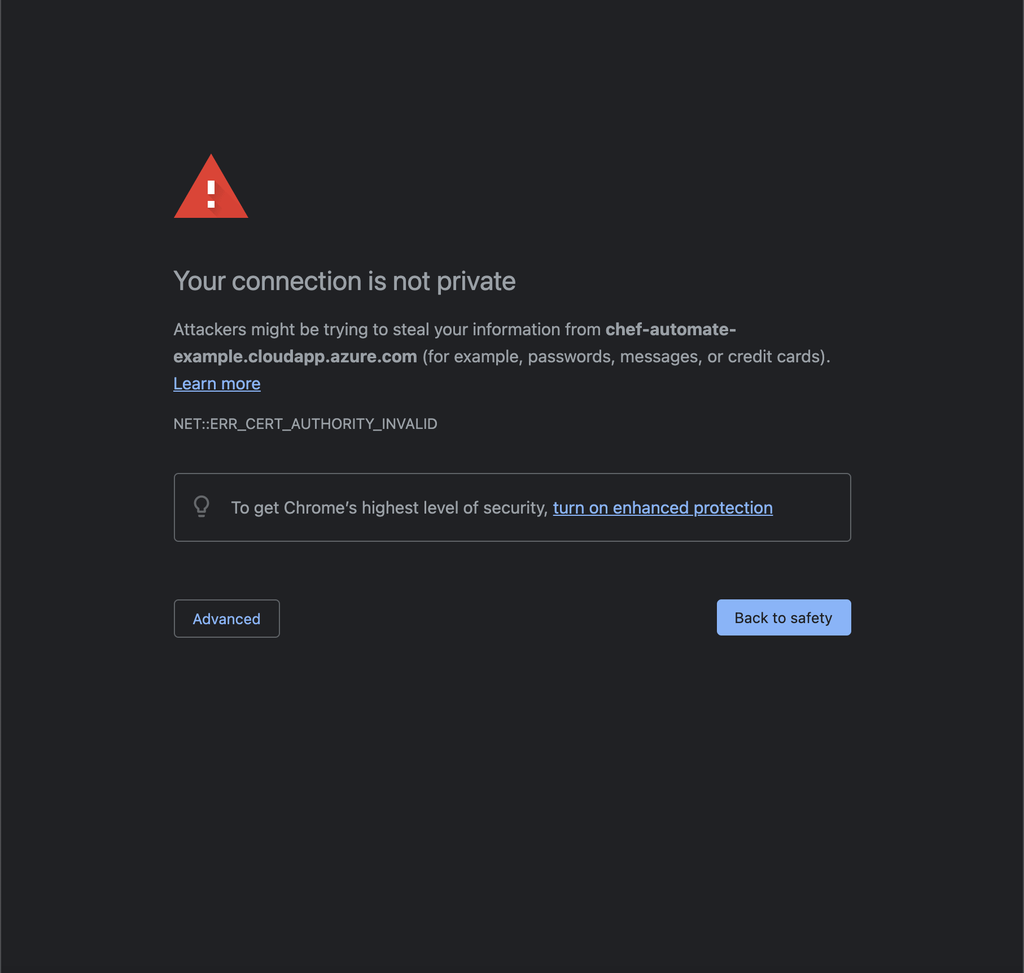

3. Enter your username, password and select **Sign In to Access Chef Automate WebUI**.

[figure not shown]

4. Enter your name and email address, accept the Chef license, and then select **Register**.

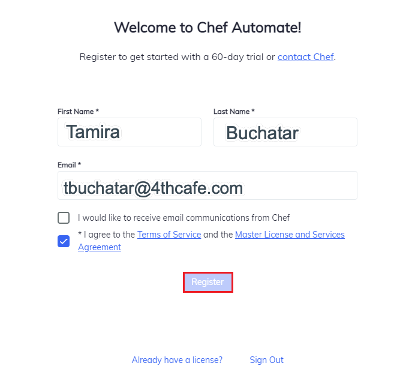

5. Congratulations! You’re ready to explore Chef Automate!

[figure not shown]